# Notebook 12 – Solutions

## Getting Started

Before running this notebook, select “Session > Restart R and Clear Output” in the menu above to start a new R session. This will clear any old data sets and give us a blank slate to start with.

## Penguin Practice

Today we are going to look at the dataset features on the in-class portion of Exam 1. We will read the data in below:

```r
penguins <- read_csv("../data/penguins.csv") |>
  filter(!is.na(sex))
penguins
```

```
## # A tibble: 333 × 8
##    species island bill_length_mm bill_depth_mm flipper_length_mm body_mass_g
##    <chr>   <chr>           <dbl>         <dbl>             <dbl>       <dbl>
##  1 Adelie  Torge…           39.1          18.7               181        3750
##  2 Adelie  Torge…           39.5          17.4               186        3800
##  3 Adelie  Torge…           40.3          18                 195        3250
##  4 Adelie  Torge…           36.7          19.3               193        3450
##  5 Adelie  Torge…           39.3          20.6               190        3650
##  6 Adelie  Torge…           38.9          17.8               181        3625
##  7 Adelie  Torge…           39.2          19.6               195        4675
##  8 Adelie  Torge…           41.1          17.6               182        3200
##  9 Adelie  Torge…           38.6          21.2               191        3800
## 10 Adelie  Torge…           34.6          21.1               198        4400
## # ℹ 323 more rows
## # ℹ 2 more variables: sex <chr>, year <dbl>
```

For the first question, create a scatterplot with body mass on the x-axis and bill length on the y-axis. Color the points based on the sex of the penguin.

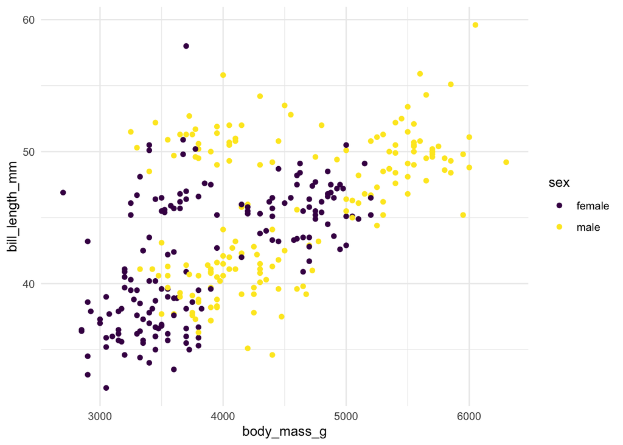

```r
# Question 01
penguins |>
  ggplot(aes(body_mass_g, bill_length_mm)) +
    geom_point(aes(color = sex)) +
    scale_color_viridis_d()
```

For the second question, we will again a scatterplot with body mass on the x-axis and bill length on the y-axis. Color the points based on the species of the penguin; use the shape aesthetic to indicate the sex of the penguin. Take a moment to understand the pattern(s) the arise in the data.

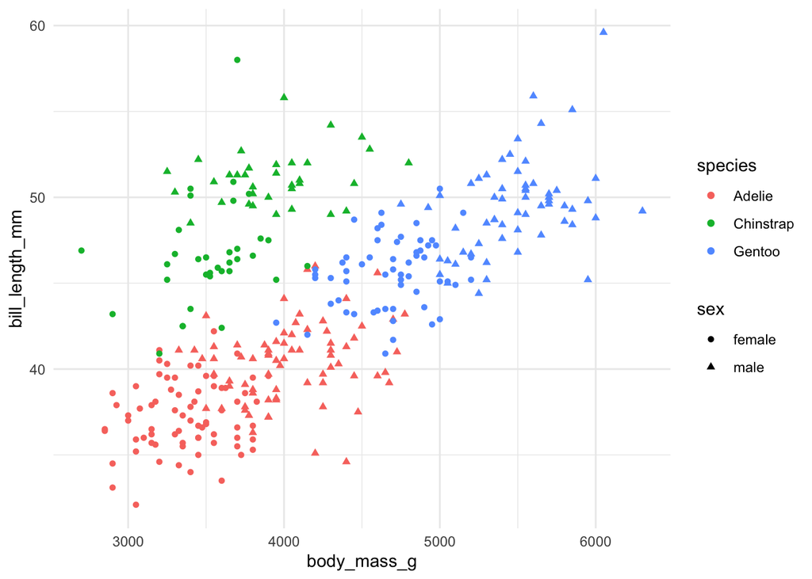

```r
# Question 02
penguins |>
  ggplot(aes(body_mass_g, bill_length_mm)) +
    geom_point(aes(color = species, shape = sex))
```

Now, let’s create a similar scatter plot with mass on the x-axis, bill length on the y-axis, color designating species, and sex indicated by shape. However, instead of showing individual penguins, create a scatterplot showing the average body mass and bill length of all penguins from the same species and sex. Your plot should have exactly six points.

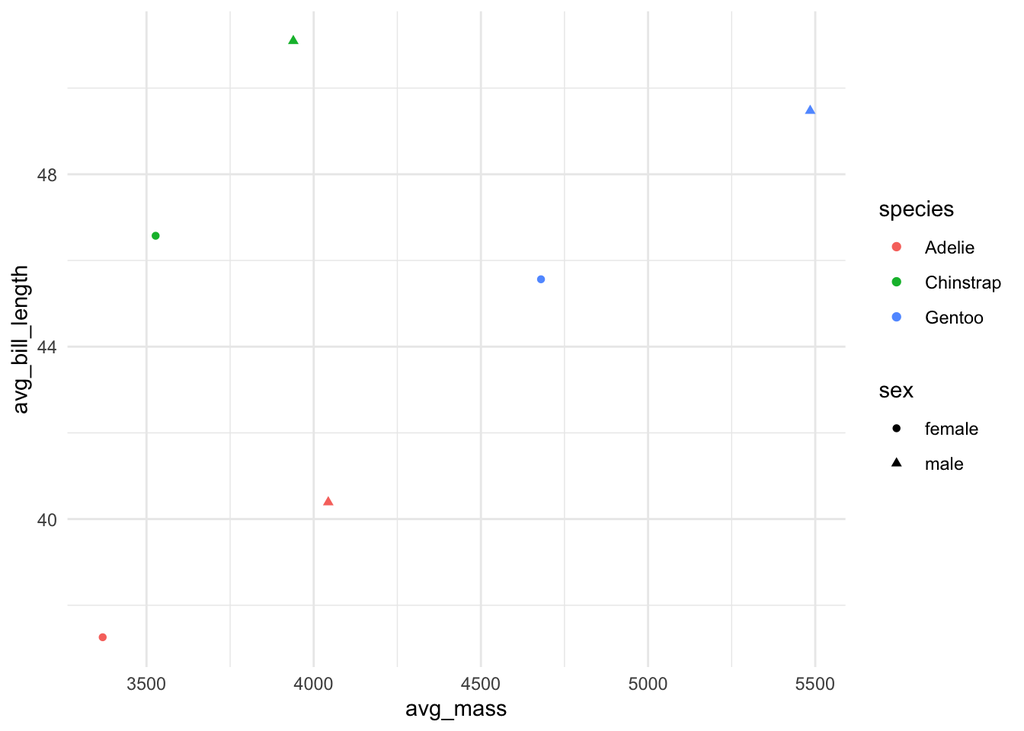

```r
# Question 03
penguins |>
  group_by(species, sex) |>
  summarize(avg_mass = mean(body_mass_g), avg_bill_length = mean(bill_length_mm)) |>
  ggplot(aes(avg_mass, avg_bill_length)) +
    geom_point(aes(color = species, shape = sex))
```

Let’s create a small table in R that gives the scientific names of the penguins.

```r
latin_names <- tibble(
  common_name = c("Adelie", "Chinstrap", "Gentoo"),
  scientific_name = c("Pygoscelis adeliae", "Pygoscelis antarcticus", "Pygoscelis papua")
)
latin_names
```

```
## # A tibble: 3 × 2
##   common_name scientific_name
##   <chr>       <chr>
## 1 Adelie      Pygoscelis adeliae
## 2 Chinstrap   Pygoscelis antarcticus
## 3 Gentoo      Pygoscelis papua
```

For the next question, re-create the plot from question 3, but make the color legend correspond to the Latin name of each penguin species rather than the common name.

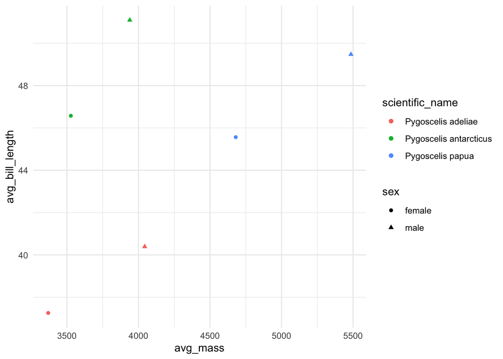

```r
# Question 04
penguins |>
  group_by(species, sex) |>
  summarize(avg_mass = mean(body_mass_g), avg_bill_length = mean(bill_length_mm)) |>
  left_join(latin_names, by = c("species" = "common_name")) |>
  ggplot(aes(avg_mass, avg_bill_length)) +
    geom_point(aes(color = scientific_name, shape = sex))
```

In the next question, we want to visualize the same information as above but instead of using two differently shaped point to designate the two different sexes of penguins within a species, we want to have an arrow for each species going from the female point to the male point. This involves using a pivot; note that you can pass multiple columns to the `values_from` argument, and will likely need to do this to complete the question. You can keep the scientific names in the legend.

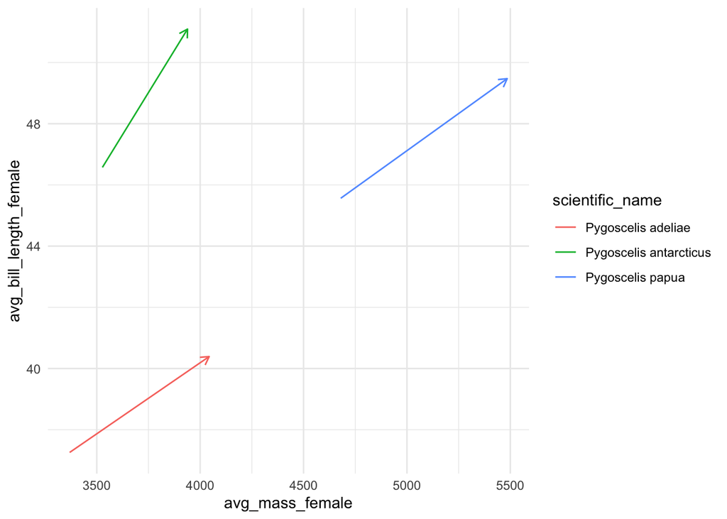

```r
# Question 05
penguins |>
  group_by(species, sex) |>
  summarize(avg_mass = mean(body_mass_g), avg_bill_length = mean(bill_length_mm)) |>
  pivot_wider(names_from = sex, values_from = c(avg_mass, avg_bill_length)) |>
  left_join(latin_names, by = c("species" = "common_name")) |>
  ggplot(aes(avg_mass_female, avg_bill_length_female)) +
    geom_segment(
      aes(color = scientific_name, xend = avg_mass_male, yend = avg_bill_length_male),
      arrow = arrow(length = unit(0.02, "npc"))
    )
```

Finally, re-create the plot from question 5, but add labels giving an appropriate title and names to all of the aesthetics.

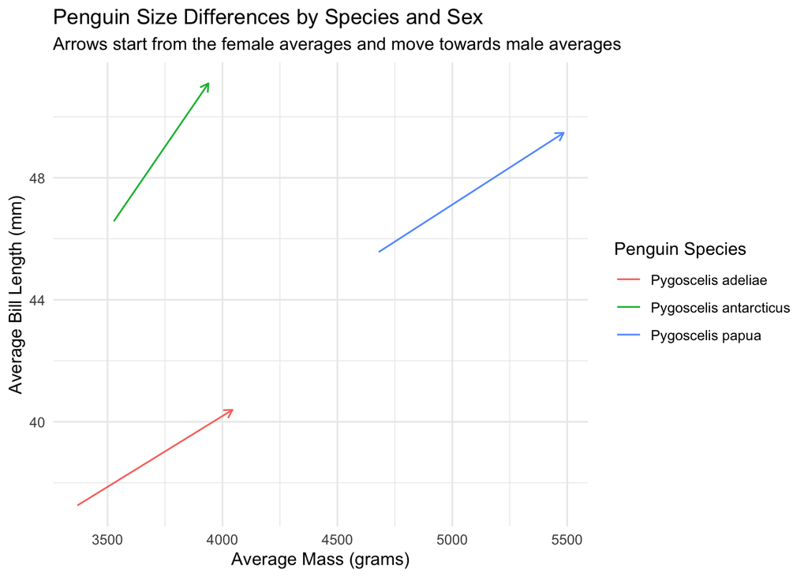

```r
# Question 06
penguins |>
  group_by(species, sex) |>
  summarize(avg_mass = mean(body_mass_g), avg_bill_length = mean(bill_length_mm)) |>
  pivot_wider(names_from = sex, values_from = c(avg_mass, avg_bill_length)) |>
  left_join(latin_names, by = c("species" = "common_name")) |>
  ggplot(aes(avg_mass_female, avg_bill_length_female)) +
    geom_segment(
      aes(color = scientific_name, xend = avg_mass_male, yend = avg_bill_length_male),
      arrow = arrow(length = unit(0.02, "npc"))
    ) +
    labs(title = "Penguin Size Differences by Species and Sex",
         subtitle = "Arrows start from the female averages and move towards male averages",
         x = "Average Mass (grams)",
         y = "Average Bill Length (mm)",
         color = "Penguin Species")
```